# LAB 1: Data pre-processing

Lluís A. Belanche, translated to R Markdown by Marta Arias

February 2020

Pre-processing is a necessary step prior to any analytical work that prepares and shapes a new dataset for further analysis. Each dataset is different and therefore it requires a different approach in what concerns data cleaning and preparation. This pre-process is crucial because it can have a deep impact on future performance and results. Moreover, it can take a significant part of your time. As an informal guide, you shall pay attention to the following aspects (not necessarily in this order):

1. treatment of lost values (missing values)
2. treatment of anomalous values (outliers)
3. treatment of incoherent or incorrect values
4. elimination of irrelevant variables
5. (possible) elimination of redundant variables
6. coding of non-continuous or non-ordered variables (nominal or binary)
7. extraction of new variables that can be useful
8. normalization of the variables (e.g. standardization)
9. transformation of the variables (e.g. correction of skewness and/or kurtosis)

In this guide, we present examples of these pre-processing steps with the example dataset `credsco.csv` provided to you along with this notebook.

```r
# we will be using routines in the accompanying script:
source("auxiliary.R")
```

#### SECTION 1: Reading the data file `credsco.csv`

Reading properly a data set is non-trivial because you need to know how the data is formatted. Things to look at are: what is the decimal separator, what is the column separator, is there a header?, how are strings quoted, how (if any) are missing values encoded?, should character vectors be converted to factors?, should white spaces be stripped?, etc.

It is a good idea to consult the help on the reading command `?read.csv` and play with useful control parameters, like

```
# header=TRUE
# na.strings="?"
# dec = "."
# sep = ";"
# quote = "\"
```

After opening the file `credsco.csv` and inspecting it with any text editor, we decide on the following settings for the `read.csv` command:

```r
Credit = read.csv("credsco.csv", header = TRUE, quote = "\"", dec = ".", check.names=TRUE)
```

The dimensions of the data set are 4,455 examples described by 14 variables, which you can figure out with the `dim` command:

```r
dim(Credit)
```

```
[1] 4455   14
```

This dataset contains data for clients of a bank, in particular regarding whether they have been assessed positively or negatively for a credit loan. This dataset is typically used to train classifiers that predict whether a client will be granted a loan or not (so, the target variable is `Assessment`; it has two possible values – however we observe a strange row with a 3rd possible value).

```r
# what are the variables?
names(Credit)
```

```
 [1] "Assessment"       "YearsInJob"       "Housing"          "Deadline"
 [5] "Age"              "MaritalStatus"    "Records"          "TypeOfJob"
 [9] "Expenses"         "Income"           "Capital"          "ChargesOnCapital"
[13] "AmountRequested"  "MarketPrice"
```

```r
# count frequence of values for target variable
table(Credit$Assessment)
```

```
   0    1    2
   1 3200 1254
```

```r
# inspect the first 4 examples
Credit[1:4,]
```

|  | Assessment | YearsInJob | Housing | Deadline | Age | MaritalStatus | Records | TypeOfJob | Expenses | Income | Capital | ChargesOnCapital | AmountRequested | MarketPrice |
| --- | --- | --- | --- | --- | --- | --- | --- | --- | --- | --- | --- | --- | --- | --- |
| 1 | 1 | 9 | 1 | 60 | 30 | 2 | 1 | 3 | 73 | 129 | 0 | 0 | 800 | 846 |
| 2 | 1 | 17 | 1 | 60 | 58 | 3 | 1 | 1 | 48 | 131 | 0 | 0 | 1000 | 1658 |
| 3 | 2 | 10 | 2 | 36 | 46 | 2 | 2 | 3 | 90 | 200 | 3000 | 0 | 2000 | 2985 |
| 4 | 1 | 0 | 1 | 60 | 24 | 1 | 1 | 1 | 63 | 182 | 2500 | 0 | 900 | 1325 |

```r
# inspect predictive variables 4, 5, 6 and 7 for the first example
Credit[1,5:8]
```

|  | Age | MaritalStatus | Records | TypeOfJob |
| --- | --- | --- | --- | --- |
| 1 | 30 | 2 | 1 | 3 |

#### SECTION 2: Basic inspection of the dataset

Have a look at the minimum and maximum values for each variable; find possible errors and abnormal values (outliers); find possible missing values; decide which variables are continuous and which are categorical; if there are mixed types, we have three options: recode continuous to categorical, recode categorical to continuous or leave them as they are. Try to get a first idea of the best decision for each issue.

```r
# always have a look at basic statistics of each variable in your data
summary(Credit)
```

```
   Assessment      YearsInJob        Housing         Deadline          Age
 Min.   :0.000   Min.   : 0.000   Min.   :0.000   Min.   : 6.00   Min.   :18.00
 1st Qu.:1.000   1st Qu.: 2.000   1st Qu.:2.000   1st Qu.:36.00   1st Qu.:28.00
 Median :1.000   Median : 5.000   Median :2.000   Median :48.00   Median :36.00
 Mean   :1.281   Mean   : 7.987   Mean   :2.657   Mean   :46.44   Mean   :37.08
 3rd Qu.:2.000   3rd Qu.:12.000   3rd Qu.:4.000   3rd Qu.:60.00   3rd Qu.:45.00
 Max.   :2.000   Max.   :48.000   Max.   :6.000   Max.   :72.00   Max.   :68.00
 MaritalStatus      Records        TypeOfJob        Expenses
 Min.   :0.000   Min.   :1.000   Min.   :0.000   Min.   : 35.00
 1st Qu.:2.000   1st Qu.:1.000   1st Qu.:1.000   1st Qu.: 35.00
 Median :2.000   Median :1.000   Median :1.000   Median : 51.00
 Mean   :1.879   Mean   :1.174   Mean   :1.676   Mean   : 55.57
 3rd Qu.:2.000   3rd Qu.:1.000   3rd Qu.:3.000   3rd Qu.: 72.00
 Max.   :5.000   Max.   :2.000   Max.   :4.000   Max.   :180.00
     Income            Capital         ChargesOnCapital   AmountRequested
 Min.   :       0   Min.   :       0   Min.   :       0   Min.   : 100
 1st Qu.:      80   1st Qu.:       0   1st Qu.:       0   1st Qu.: 700
 Median :     120   Median :    3500   Median :       0   Median :1000
 Mean   :  763317   Mean   : 1060341   Mean   :  404382   Mean   :1039
 3rd Qu.:     166   3rd Qu.:    6000   3rd Qu.:       0   3rd Qu.:1300
 Max.   :99999999   Max.   :99999999   Max.   :99999999   Max.   :5000
  MarketPrice
 Min.   :  105
 1st Qu.: 1118
 Median : 1400
 Mean   : 1463
 3rd Qu.: 1692
 Max.   :11140
```

From the summary, we observe the following:

- `Assessment`,`Housing`,`MaritalStatus`,`Records`,`TypeOfJob` are categorical and need to be treated properly. In particular, `Assessment` is the target variable; we need to identify correct values
- `Capital`, `ChargesOnCapital` and `Income` present abnormally high maximums (99999999)
- there are also suspicious zeros, in both types of variables, which we identify with missing values

#### SECTION 3: Dealing with *missing values*

Make a decision on a sensible treatment for the missing values and apply it; it is wise to write down the possible consequences of this decision and the alternatives that could be considered in case the final results are not satisfactory

The easiest way is of course to eliminate the involved rows or columns; this can be done partially. For example, we could decide to eliminate the variables with the highest proportion of missing values. Deleting instances and/or variables containing missing values results in loss of relevant data and is also frustrating because of the effort in collecting the sacrificed information.

**CAREFUL!** R does not know magically which entries are missing values

```r
# this does not do anything, because there are no explicitly declared NA's
Credit.complete = na.omit(Credit)
dim(Credit.complete)
```

```
[1] 4455   14
```

The previous code does nothing, because missing values are not encoded as NA in our data.

In the present case we have decided to perform a step-by-step treatment, separate for the categorical and continuous information.

First, we decide to remove those rows with with missing values in the categorical variables (there are few), which in our data are encoded with a `0`.

```r
table(Credit[,"Assessment"]==0)
```

```
FALSE  TRUE
 4454     1
```

```r
table(Credit[,"Housing"]==0)
```

```
FALSE  TRUE
 4449     6
```

```r
table(Credit[,"MaritalStatus"]==0)
```

```
FALSE  TRUE
 4454     1
```

```r
table(Credit[,"TypeOfJob"]==0)
```

```
FALSE  TRUE
 4453     2
```

Since there aren’t too many, we remove those rows with a 0 in these variables:

```r
Credit = Credit[Credit[,"Assessment"] != 0 & Credit[,"Housing"] != 0 &
                 Credit[,"MaritalStatus"] != 0 & Credit[,"TypeOfJob"] != 0,]

dim(Credit)
```

```
[1] 4446   14
```

This process removed 9 rows.

Now we process rows with missing values in the continuous variables (code 99999999). To avoid having to write each time the `Credit$...` part, we use the `attach` command.

```r
attach(Credit)
```

However, beware:

**WARNING!** `attach` allows access to the values of columns of a data frame for reading (access) only, and as they were when attached, but does not modify the dataframe

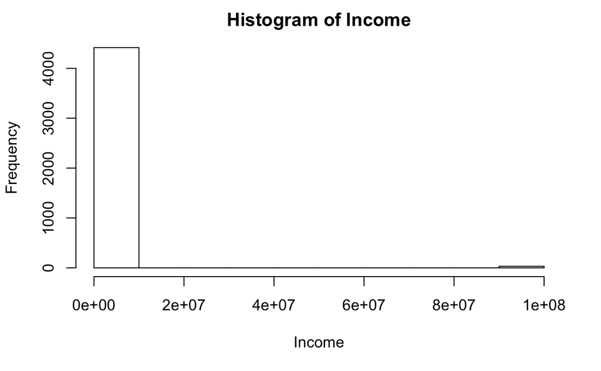

```r
hist(Income)
```

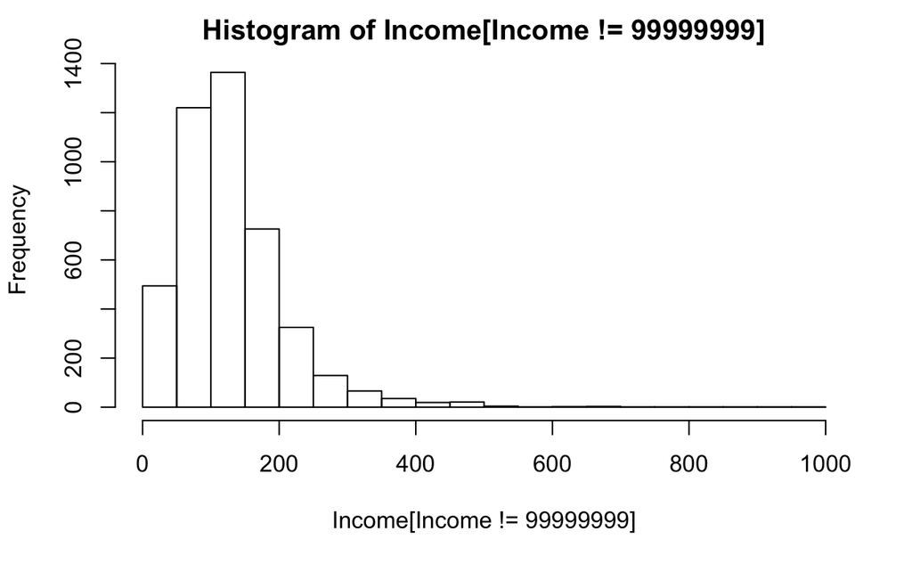

```r
hist(Income[Income != 99999999])
```

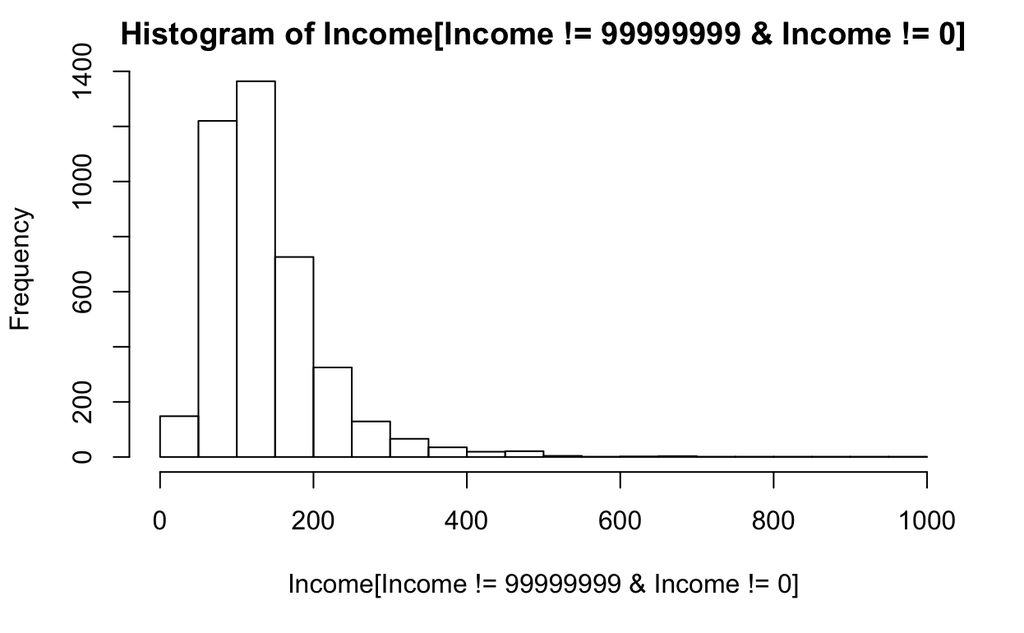

```r
hist(Income[Income != 99999999 & Income != 0], breaks=15)
```

These values are clearly incorrect!

```r
table(Income == 99999999)
```

```
FALSE  TRUE
 4415    31
```

```r
table(Income == 0)
```

```
FALSE  TRUE
 4100   346
```

```r
table(Capital == 99999999)
```

```
FALSE  TRUE
 4405    41
```

```r
table(ChargesOnCapital == 99999999)
```

```
FALSE  TRUE
 4434    12
```

What do we do with this one? well, let’s assume it is correct …

```r
table(YearsInJob == 0)
```

```
FALSE  TRUE
 3914   532
```

Continuous variables have too many missing values, we can not eliminate them just like that: we must devise a treatment for these missing values (we will **impute** the missing values, see below).

First, we declare them as `NA`, including those from no `Income`

```r
Income[Income == 99999999 | Income == 0] = NA
Capital[Capital == 99999999] = NA
ChargesOnCapital[ChargesOnCapital == 99999999] = NA
```

```r
# see the difference
summary(Income)
```

```
   Min. 1st Qu.  Median    Mean 3rd Qu.    Max.    NA's
    6.0    90.0   125.0   141.7   170.0   959.0     377
```

```r
summary(Credit$Income)
```

```
    Min.  1st Qu.   Median     Mean  3rd Qu.     Max.
       0       80      120   697386      166 99999999
```

##### Imputation of NA’s for continuous variables

Imputation by **nearest neighbour**: for every observation with a missing `Income`, we look for the most similar observation (according to the remaining variables) and copy its `Income` value.

```r
# Imputation of 'Income', 'Capital' and 'ChargesOnCapital'
Income = knn.imputation (Income, "Income")
Capital = knn.imputation (Capital, "Capital")
ChargesOnCapital = knn.imputation (ChargesOnCapital, "ChargesOnCapital")

ChargesOnCapital[Capital==0] = 0
```

Don’t forget to assign back to the dataframe

```r
Credit[,"Income"] = Income
Credit[,"Capital"] = Capital
Credit[,"ChargesOnCapital"] = ChargesOnCapital
```

Inspect again the result, especially the new statistics

```r
dim(Credit)
```

```
[1] 4446   14
```

```r
summary(Credit)
```

```
   Assessment      YearsInJob        Housing        Deadline          Age
 Min.   :1.000   Min.   : 0.000   Min.   :1.00   Min.   : 6.00   Min.   :18.00
 1st Qu.:1.000   1st Qu.: 2.000   1st Qu.:2.00   1st Qu.:36.00   1st Qu.:28.00
 Median :1.000   Median : 5.000   Median :2.00   Median :48.00   Median :36.00
 Mean   :1.281   Mean   : 7.991   Mean   :2.66   Mean   :46.45   Mean   :37.08
 3rd Qu.:2.000   3rd Qu.:12.000   3rd Qu.:4.00   3rd Qu.:60.00   3rd Qu.:45.00
 Max.   :2.000   Max.   :48.000   Max.   :6.00   Max.   :72.00   Max.   :68.00
 MaritalStatus     Records        TypeOfJob        Expenses         Income
 Min.   :1.00   Min.   :1.000   Min.   :1.000   Min.   : 35.0   Min.   :  6.0
 1st Qu.:2.00   1st Qu.:1.000   1st Qu.:1.000   1st Qu.: 35.0   1st Qu.: 90.0
 Median :2.00   Median :1.000   Median :1.000   Median : 51.0   Median :125.0
 Mean   :1.88   Mean   :1.173   Mean   :1.676   Mean   : 55.6   Mean   :142.6
 3rd Qu.:2.00   3rd Qu.:1.000   3rd Qu.:3.000   3rd Qu.: 72.0   3rd Qu.:173.0
 Max.   :5.00   Max.   :2.000   Max.   :4.000   Max.   :180.0   Max.   :959.0
    Capital       ChargesOnCapital  AmountRequested  MarketPrice
 Min.   :     0   Min.   :    0.0   Min.   : 100    Min.   :  105
 1st Qu.:     0   1st Qu.:    0.0   1st Qu.: 700    1st Qu.: 1116
 Median :  3000   Median :    0.0   Median :1000    Median : 1400
 Mean   :  5596   Mean   :  342.3   Mean   :1039    Mean   : 1462
 3rd Qu.:  6000   3rd Qu.:    0.0   3rd Qu.:1300    3rd Qu.: 1692
 Max.   :300000   Max.   :30000.0   Max.   :5000    Max.   :11140
```

#### SECTION 4: Treatment of mixed data types

First we explicitly declare some variables as categorical (‘factor’ in R)

```r
Assessment = as.factor(Assessment)
Housing = as.factor(Housing)
MaritalStatus = as.factor(MaritalStatus)
Records = as.factor(Records)
TypeOfJob = as.factor(TypeOfJob)

levels(Assessment)
```

```
[1] "1" "2"
```

```r
levels(Housing)
```

```
[1] "1" "2" "3" "4" "5" "6"
```

```r
levels(MaritalStatus)
```

```
[1] "1" "2" "3" "4" "5"
```

```r
levels(Records)
```

```
[1] "1" "2"
```

```r
levels(TypeOfJob)
```

```
[1] "1" "2" "3" "4"
```

These level codes are not very nice (not very meaningful), let’s recode:

```r
levels(Assessment) = c("positive","negative")
levels(Housing) = c("rent","owner","private","ignore","parents","other")
levels(MaritalStatus) = c("single","married","widower","split","divorced")
levels(Records) = c("no","yes")
levels(TypeOfJob) = c("indefinite","temporal","self-employed","other")
```

As a reminder of dataframe access (i.e., behaviour with `attach`):

```r
is.factor(Assessment)
```

```
[1] TRUE
```

```r
is.factor(Credit[,"Assessment"])
```

```
[1] FALSE
```

#### SECTION 5: Derivation of new variables (a.k.a. feature extraction)

Decide whether it can be sensible to derive new variables; we decide to extract two new continuous and one new categorical variable (for the sake of illustration):

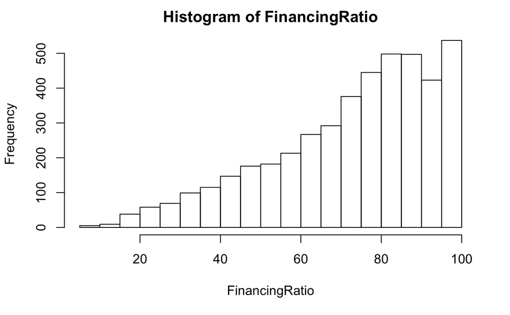

```r
# Financing ratio (continuous)
FinancingRatio = 100*AmountRequested/MarketPrice
hist(FinancingRatio)
```

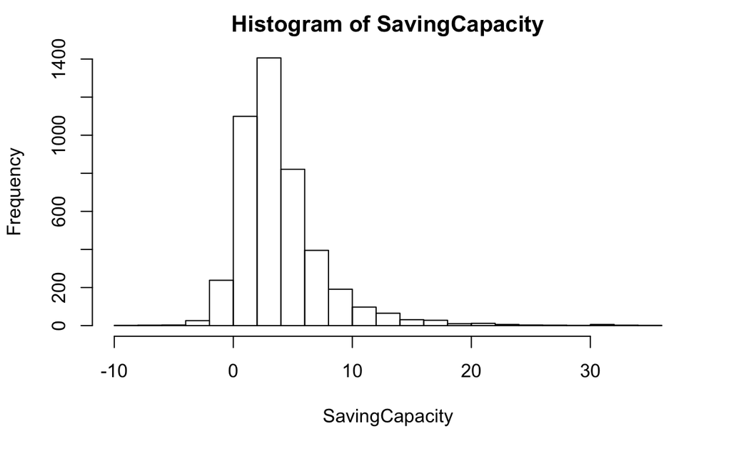

```r
# Saving capacity (continuous)
SavingCapacity = (Income-Expenses-(ChargesOnCapital/100))/(AmountRequested/Deadline)
hist(SavingCapacity, breaks=16)
```

```r
# Amount Requested greater than 1.2 times the median by people 1.5 times older than the mean (categorical):
Dubious = rep("No", nrow(Credit))
Dubious[AmountRequested > 1.2*median(AmountRequested, na.rm = TRUE) & Age > 1.5*mean (Age, na.rm = TRUE)] = "Yes"
Dubious = as.factor(Dubious)

table(Dubious,Assessment)
```

```
       Assessment
Dubious positive negative
    No      3156     1227
    Yes       41       22
```

#### SECTION 6: Putting together what we have done so far

```r
# create a new dataframe that gathers everything and inspect it again

Credit.new = data.frame(Assessment,YearsInJob,Housing,Deadline,Age,MaritalStatus,Records,TypeOfJob,Expenses,Income,Capital,ChargesOnCapital,AmountRequested,MarketPrice,FinancingRatio,SavingCapacity,Dubious)

summary(Credit.new)
```

```
    Assessment     YearsInJob        Housing        Deadline          Age
 positive:3197   Min.   : 0.000   rent   : 973   Min.   : 6.00   Min.   :18.00
 negative:1249   1st Qu.: 2.000   owner  :2106   1st Qu.:36.00   1st Qu.:28.00
                 Median : 5.000   private: 246   Median :48.00   Median :36.00
                 Mean   : 7.991   ignore :  20   Mean   :46.45   Mean   :37.08
                 3rd Qu.:12.000   parents: 782   3rd Qu.:60.00   3rd Qu.:45.00
                 Max.   :48.000   other  : 319   Max.   :72.00   Max.   :68.00
  MaritalStatus  Records            TypeOfJob       Expenses         Income
 single  : 973   no :3677   indefinite   :2803   Min.   : 35.0   Min.   :  6.0
 married :3238   yes: 769   temporal     : 451   1st Qu.: 35.0   1st Qu.: 90.0
 widower :  67              self-employed:1021   Median : 51.0   Median :125.0
 split   : 130              other        : 171   Mean   : 55.6   Mean   :142.6
 divorced:  38                                   3rd Qu.: 72.0   3rd Qu.:173.0
                                                 Max.   :180.0   Max.   :959.0
    Capital       ChargesOnCapital  AmountRequested  MarketPrice
 Min.   :     0   Min.   :    0.0   Min.   : 100    Min.   :  105
 1st Qu.:     0   1st Qu.:    0.0   1st Qu.: 700    1st Qu.: 1116
 Median :  3000   Median :    0.0   Median :1000    Median : 1400
 Mean   :  5596   Mean   :  342.3   Mean   :1039    Mean   : 1462
 3rd Qu.:  6000   3rd Qu.:    0.0   3rd Qu.:1300    3rd Qu.: 1692
 Max.   :300000   Max.   :30000.0   Max.   :5000    Max.   :11140
 FinancingRatio    SavingCapacity   Dubious
 Min.   :  6.702   Min.   :-8.160   No :4383
 1st Qu.: 60.030   1st Qu.: 1.672   Yes:  63
 Median : 77.097   Median : 3.162
 Mean   : 72.616   Mean   : 3.944
 3rd Qu.: 88.460   3rd Qu.: 5.271
 Max.   :100.000   Max.   :35.750
```

```r
dim(Credit.new)
```

```
[1] 4446   17
```

```r
detach(Credit)
attach(Credit.new)
```

Sanity check:

```r
is.factor(Credit.new[,"Assessment"])
```

```
[1] TRUE
```

#### SECTION 7: Gaussianity and transformations

It is useful to have an idea of the empirical distribution of the dataset’s variables. One can visualize a graphical summary of some of the variables (both categorical and continuous), using the `boxplot()` and `hist()` procedures.

##### For **continuous** data: histograms and boxplots

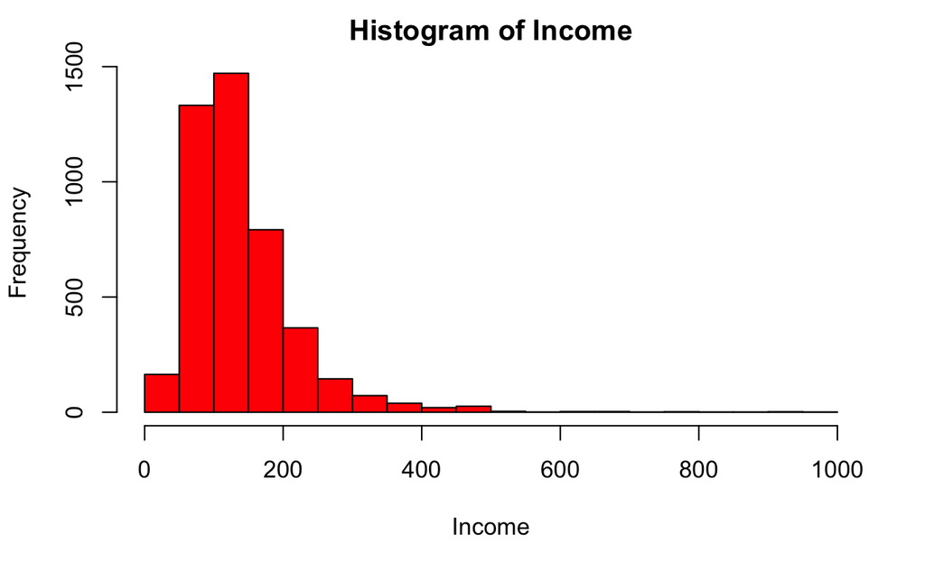

```r
hist(Income, col=2)
```

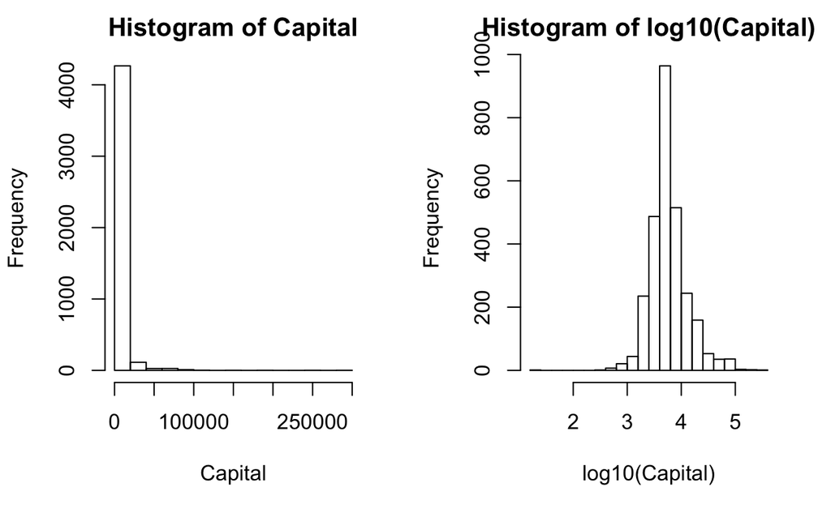

```r
par(mfrow=c(1,2))
hist(Capital)
hist(log10(Capital), breaks=20)
```

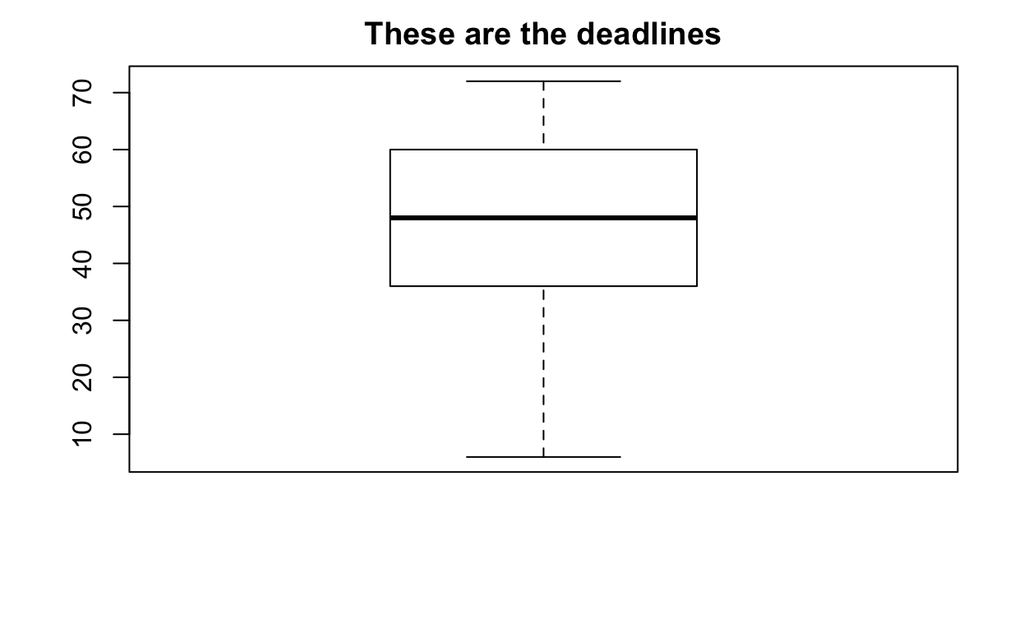

```r
boxplot(Deadline)
title ("These are the deadlines")
```

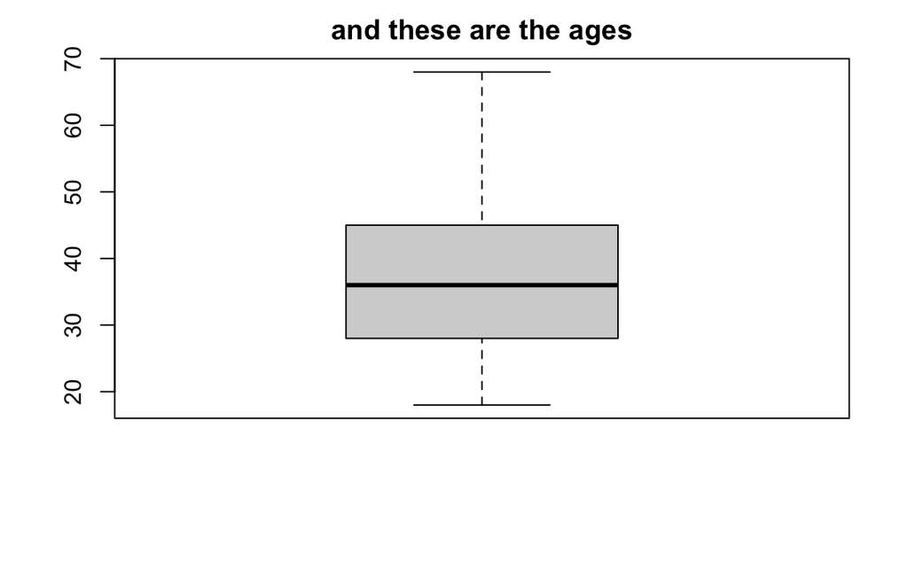

```r
boxplot(Age, col="lightgray")
title ("and these are the ages")
```

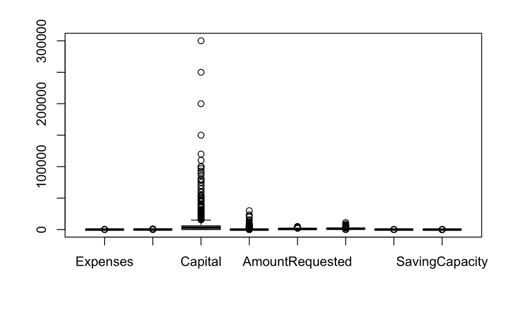

```r
boxplot(Credit.new[,9:16], outline=TRUE)
```

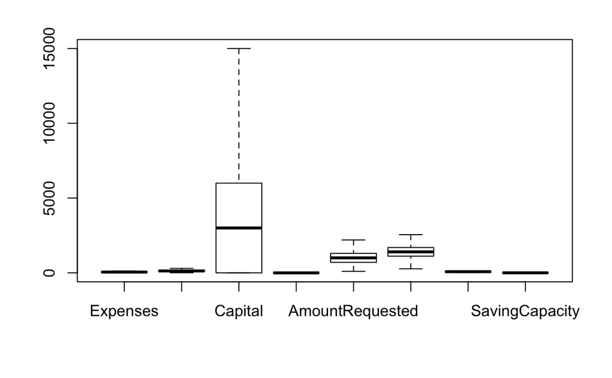

```r
boxplot(Credit.new[,9:16], outline=FALSE) # much better, but would be nicer one by one, to avoid flat boxplots
```

The previous plots suggest to take logs on some variables: `Capital` and `ChargesOnCapital` (we’ll do it later)

##### For categorical data: Frequency tables, Contingency tables, Bar charts, Pie charts

Now, should we treat Age as categorical? probably not … but if we wanted to do so, we can use `cut`:

```r
table(Age)
```

```
Age
 18  19  20  21  22  23  24  25  26  27  28  29  30  31  32  33  34  35  36  37
  8  28  49  82 112 127 152 141 163 153 178 131 156 153 159 141 155 120 145 142
 38  39  40  41  42  43  44  45  46  47  48  49  50  51  52  53  54  55  56  57
135 126 139 114 112  93  78  88  95  89  60  90  81  83  82  70  58  65  48  31
 58  59  60  61  62  63  64  65  66  68
 40  34  34  27  20  22  14  12   9   2
```

```r
summary(Age)
```

```
   Min. 1st Qu.  Median    Mean 3rd Qu.    Max.
  18.00   28.00   36.00   37.08   45.00   68.00
```

```r
(Age.cat = cut(Age, breaks = seq(30, 90, 10))) # WARNING! we are generating NAs
```

```
   [1] <NA>    (50,60] (40,50] <NA>    <NA>    (30,40] (40,50] <NA>    (30,40]
  [10] (40,50] (30,40] <NA>    <NA>    (30,40] <NA>    (60,70] (50,60] (60,70]
  [19] (30,40] (30,40] <NA>    <NA>    (40,50] (40,50] (50,60] (50,60] (40,50]
  [28] (40,50] <NA>    <NA>    <NA>    (50,60] (30,40] (30,40] (60,70] (50,60]
  [37] (30,40] (30,40] (60,70] (30,40] (40,50] (60,70] (30,40] (40,50] <NA>
  [46] (40,50] (40,50] <NA>    (50,60] <NA>    (30,40] (30,40] (50,60] (30,40]
  [55] <NA>    <NA>    <NA>    (60,70] (50,60] <NA>    (30,40] <NA>    (30,40]
  [64] (30,40] (40,50] (30,40] (30,40] (50,60] (40,50] (30,40] (40,50] (40,50]
  [73] (30,40] (40,50] (30,40] (30,40] (40,50] (50,60] (50,60] (50,60] (50,60]
  [82] <NA>    (30,40] (30,40] <NA>    <NA>    (50,60] <NA>    (60,70] <NA>
  [91] (30,40] <NA>    (30,40] (50,60] (40,50] (40,50] (50,60] (50,60] (50,60]
 [100] (50,60] (30,40] (30,40] <NA>    <NA>    (30,40] <NA>    <NA>    <NA>
 [109] (30,40] (30,40] (30,40] (50,60] (30,40] <NA>    (30,40] (30,40] (40,50]
 [118] (60,70] (30,40] (40,50] <NA>    <NA>    (50,60] (40,50] (30,40] <NA>
 [127] (50,60] <NA>    (40,50] <NA>    <NA>    <NA>    (60,70] (30,40] (40,50]
```

[output cut: 99 more lines]

```r
Age.cat = cut(Age, breaks = seq(15, 75, 10))
(Age.tab = table(Age.cat))
```

```
Age.cat
(15,25] (25,35] (35,45] (45,55] (55,65] (65,75]
    699    1509    1172     773     282      11
```

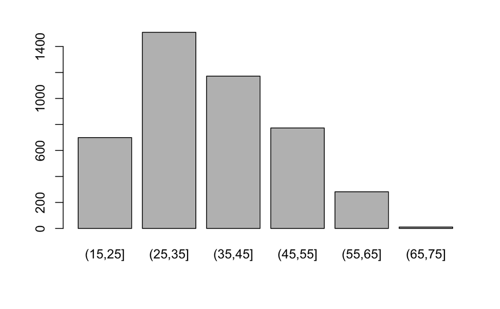

```r
barplot(Age.tab)    # bar chart
```

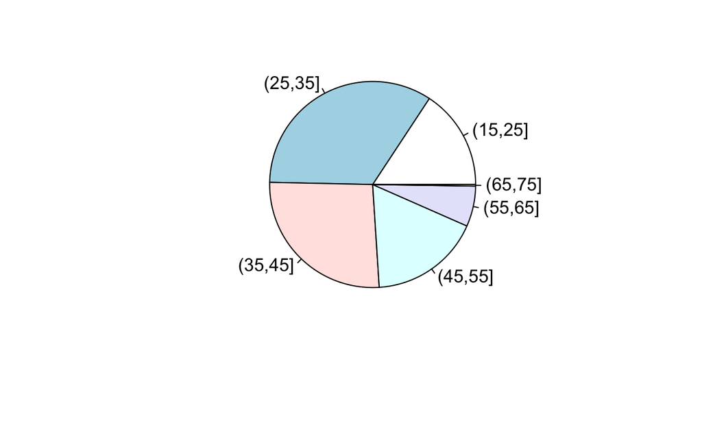

```r
pie(Age.tab)        # pie chart
```

Incidentally, this is how we could generate another new variable based on Age:

```r
Age2.cat = factor(as.integer(Age < 55))
levels(Age2.cat) = c("over55","under55")
```

With the `table` commands we can generate contingency tables for categorical variables in different flavors:

```r
(TypeOfJob.Age = table(TypeOfJob, Age.cat)) # contingency table
```

```
               Age.cat
TypeOfJob       (15,25] (25,35] (35,45] (45,55] (55,65] (65,75]
  indefinite        408    1054     742     463     132       4
  temporal          183     155      81      30       2       0
  self-employed      91     272     319     250      87       2
  other              17      28      30      30      61       5
```

```r
margin.table(TypeOfJob.Age, 1)              # row sums
```

```
TypeOfJob
   indefinite      temporal self-employed         other
         2803           451          1021           171
```

```r
margin.table(TypeOfJob.Age, 2)              # column sums
```

```
Age.cat
(15,25] (25,35] (35,45] (45,55] (55,65] (65,75]
    699    1509    1172     773     282      11
```

```r
round(prop.table(TypeOfJob.Age), digits=3)  # relative freqencies, rounded to 3 digits
```

```
               Age.cat
TypeOfJob       (15,25] (25,35] (35,45] (45,55] (55,65] (65,75]
  indefinite      0.092   0.237   0.167   0.104   0.030   0.001
  temporal        0.041   0.035   0.018   0.007   0.000   0.000
  self-employed   0.020   0.061   0.072   0.056   0.020   0.000
  other           0.004   0.006   0.007   0.007   0.014   0.001
```

```r
round(prop.table(TypeOfJob.Age) * 100, digits=1)  # total percentages
```

```
               Age.cat
TypeOfJob       (15,25] (25,35] (35,45] (45,55] (55,65] (65,75]
  indefinite        9.2    23.7    16.7    10.4     3.0     0.1
  temporal          4.1     3.5     1.8     0.7     0.0     0.0
  self-employed     2.0     6.1     7.2     5.6     2.0     0.0
  other             0.4     0.6     0.7     0.7     1.4     0.1
```

```r
round(prop.table(TypeOfJob.Age, 1), digits=3) # table of relative frequencies (row-wise)
```

```
               Age.cat
TypeOfJob       (15,25] (25,35] (35,45] (45,55] (55,65] (65,75]
  indefinite      0.146   0.376   0.265   0.165   0.047   0.001
  temporal        0.406   0.344   0.180   0.067   0.004   0.000
  self-employed   0.089   0.266   0.312   0.245   0.085   0.002
  other           0.099   0.164   0.175   0.175   0.357   0.029
```

```r
(TypeOfJob.Age.rel = round(prop.table(TypeOfJob.Age, 2), digits=3)) # table of relative frequencies (column-wise)
```

```
               Age.cat
TypeOfJob       (15,25] (25,35] (35,45] (45,55] (55,65] (65,75]
  indefinite      0.584   0.698   0.633   0.599   0.468   0.364
  temporal        0.262   0.103   0.069   0.039   0.007   0.000
  self-employed   0.130   0.180   0.272   0.323   0.309   0.182
  other           0.024   0.019   0.026   0.039   0.216   0.455
```

Other graphical representations of the distributions:

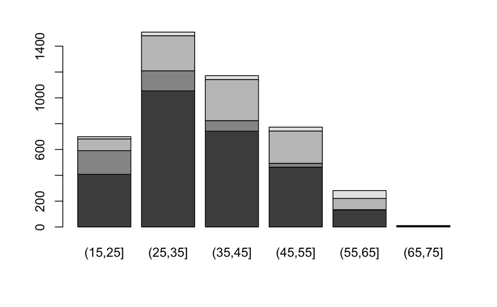

```r
barplot(TypeOfJob.Age)  # basic stacked bar chart
```

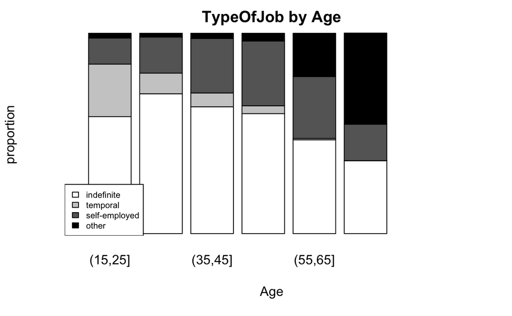

```r
barplot(TypeOfJob.Age.rel, yaxt="n", xlab="Age", ylab="proportion",
        col = c("white", "grey80", "grey40", "black"),
        main = "TypeOfJob by Age", xlim=c(0,9))   # stacked bar chart

legend("bottomleft", legend=rownames(TypeOfJob.Age.rel), col="black",
      fill = c("white", "grey80", "grey40", "black"), cex=0.65)
```

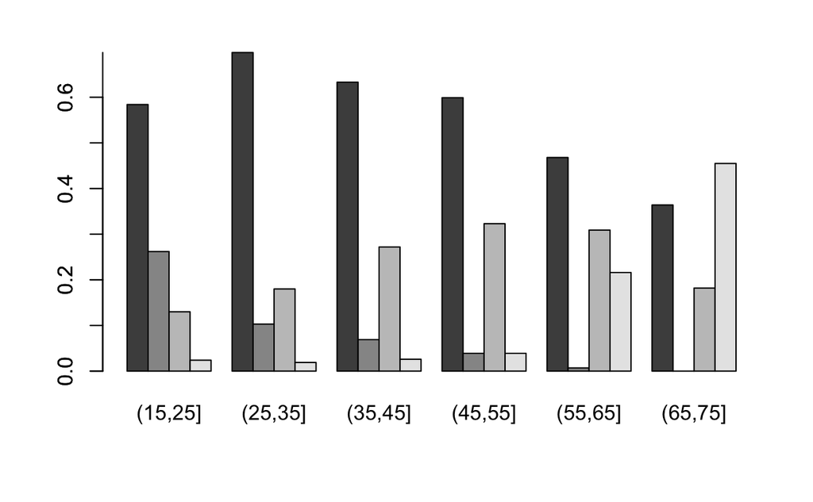

```r
barplot(TypeOfJob.Age.rel, beside = TRUE)   # grouped bar chart
axis(2, at=seq(0, 1, 0.2))
```

#### Pair-wise comparisons of variables

We can also perform graphical comparisons between some pairs of variables (both categorical and continuous), using the plot(), pairs() and identify() procedures

```r
par(mfrow=c(1,2))
plot (AmountRequested, Capital, main = "Amount req. vs. Market price",
      cex = .5, col = "dark red")

plot (log10(AmountRequested), log10(Capital+1), main = "Amount req. vs. Market price (better)", cex = .5, col = "dark red")
```

```r
# adding a center (dashed) and a regression line (blue)
abline(v = mean(log10(AmountRequested)), lty = 2, col = "grey40")
abline(h = mean(log10(Capital+1)), lty = 2, col = "grey40")
```

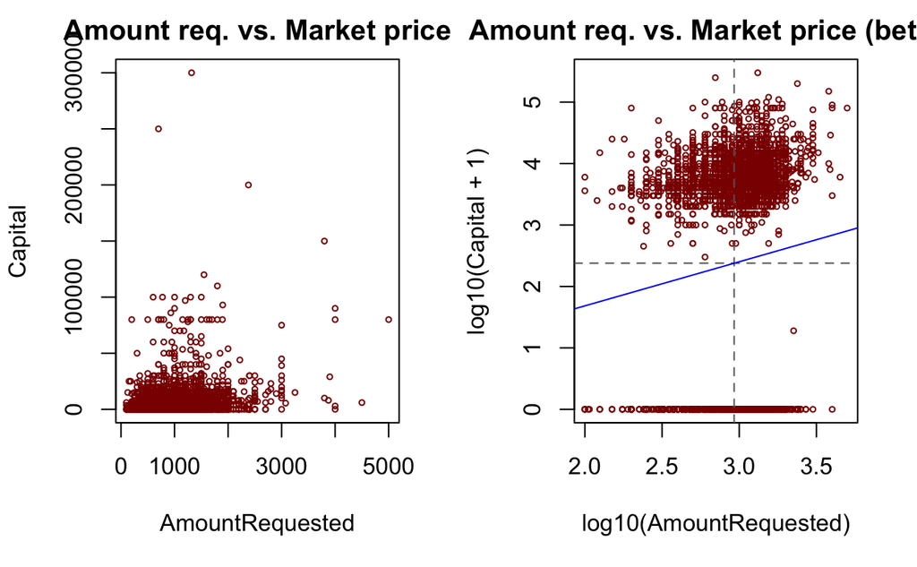

```r
abline(lm(log10(Capital+1) ~ log10(AmountRequested)), col = "blue")
```

Note that log10(x+1)=0 for x=0, so our transformation keeps the zeros. On the other hand, these same zeros spoil the regression

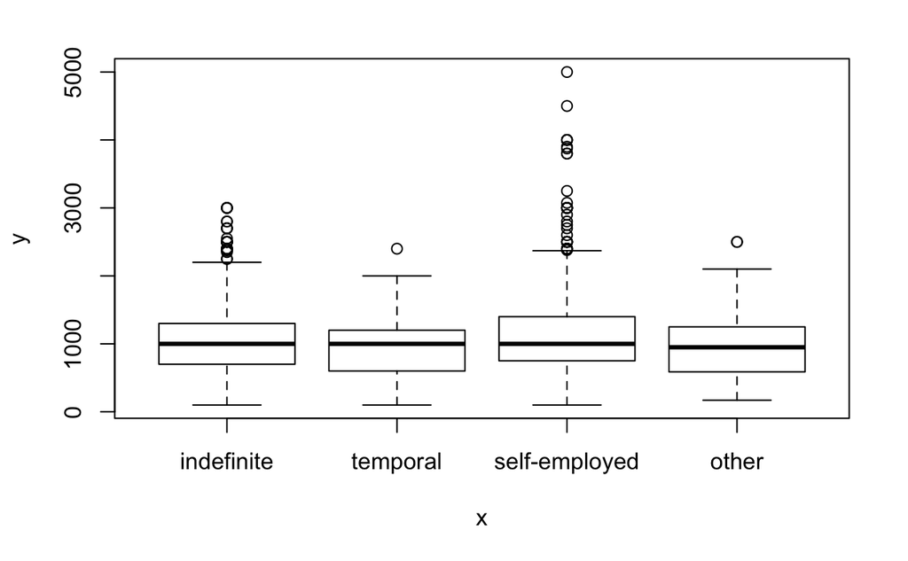

```r
par(mfrow=c(1,1))

plot (TypeOfJob, AmountRequested)
```

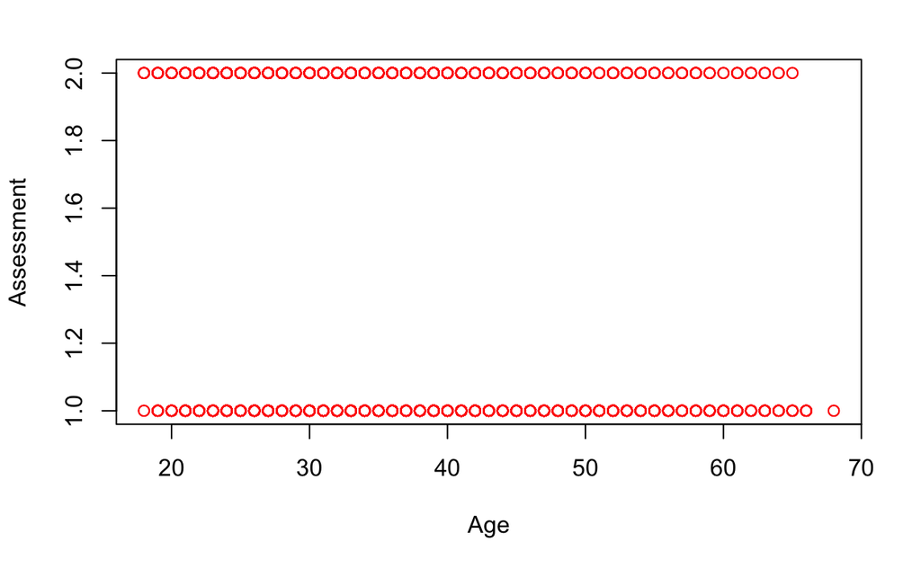

```r
plot (Age,Assessment, col="red") # WARNING!
```

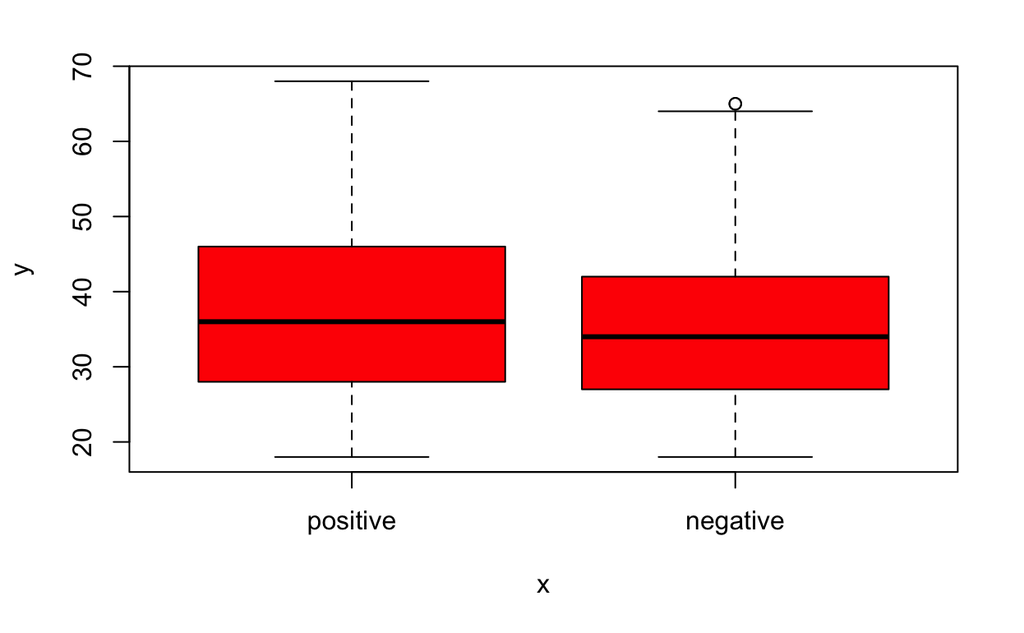

```r
plot (Assessment, Age, col="red") # better
```

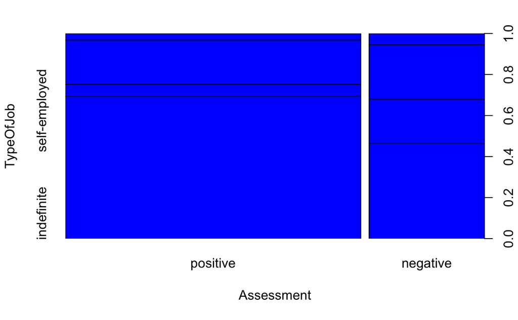

```r
plot (Assessment, TypeOfJob,col="blue", xlab="Assessment",ylab="TypeOfJob")
```

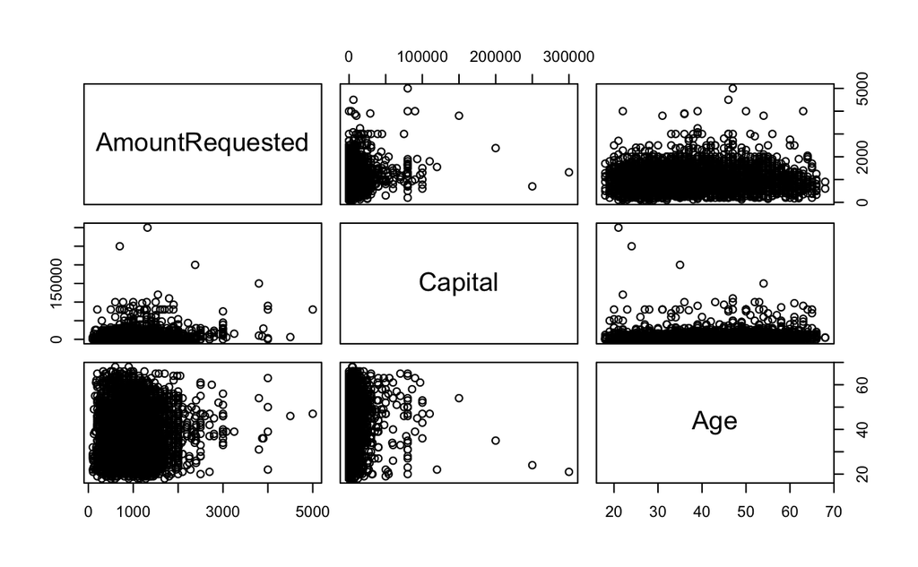

```r
pairs(~ AmountRequested + Capital + Age)
```

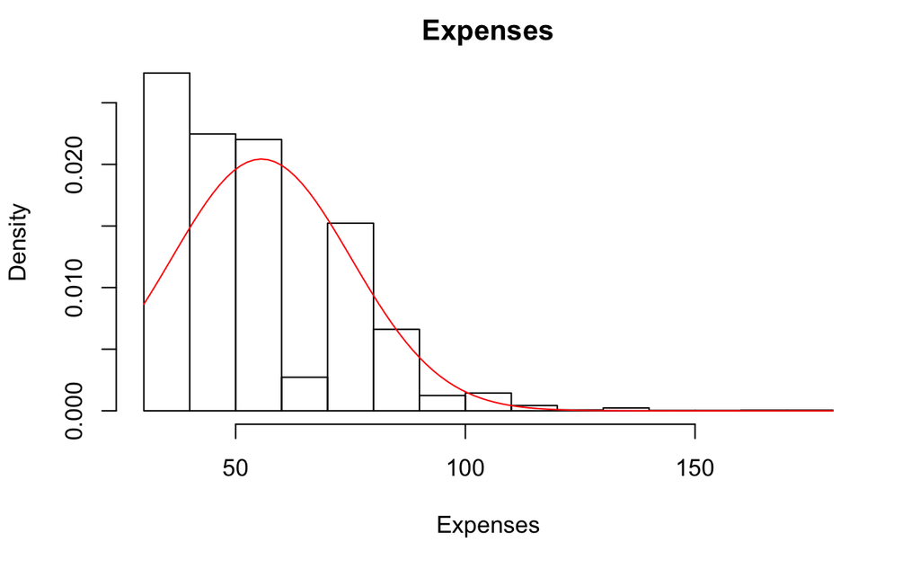

```r
# Plotting a variable against the normal pdf in red
hist.with.normal(Expenses, "Expenses")
```

Density plots for other variables:

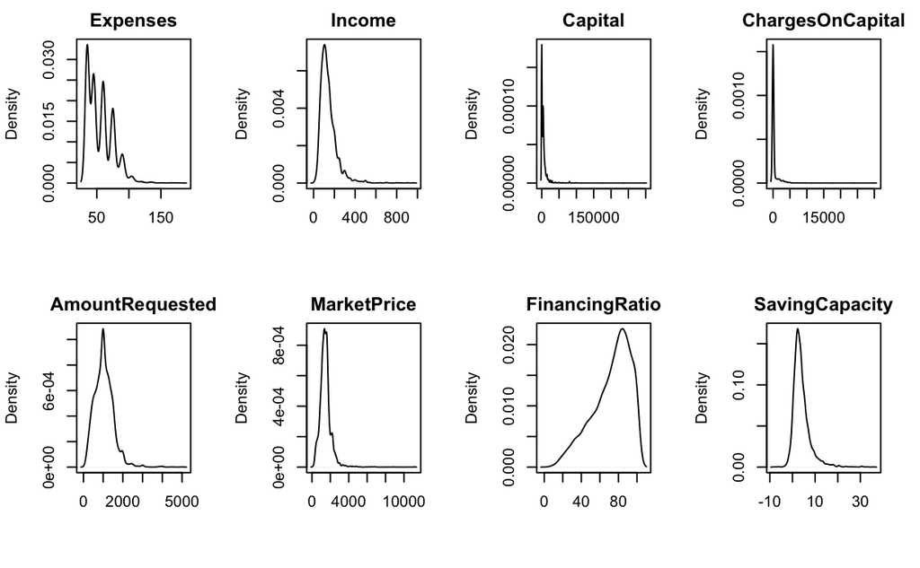

```r
par(mfrow=c(2,4))
for (i in 0:7)
  { plot(density(Credit.new[,i+9]), xlab="", main=names(Credit.new)[i+9]) }
```

Do any of the continuous variables “look” Gaussian? Features to look for in comparing to a Gaussian: outliers, asymmetries, long tails

A useful tool for “Gaussianization” is the Box-Cox power transformation

```r
library(MASS)

par(mfrow=c(1,3))

hist(Capital, main="Look at that ...")

bx = boxcox(I(Capital+1) ~ . - Assessment, data = Credit.new,
             lambda = seq(-0.25, 0.25, length = 10))
```

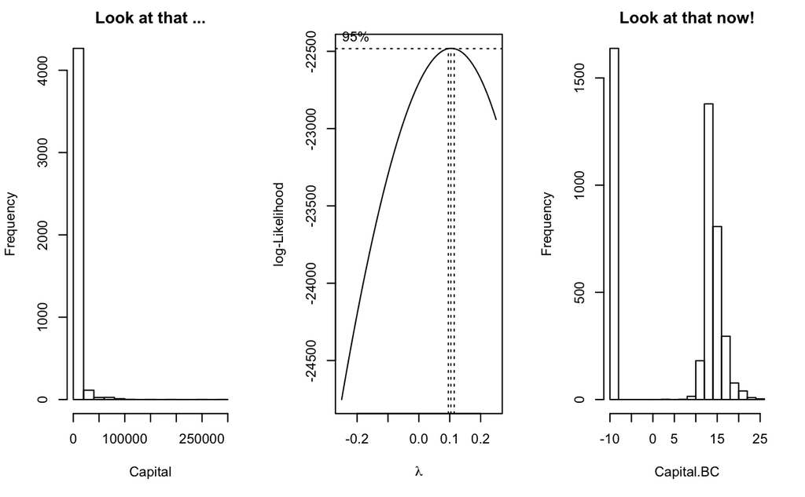

```r
lambda = bx$x[which.max(bx$y)]

Capital.BC = (Capital^lambda - 1)/lambda

hist(Capital.BC, main="Look at that now!")

par (mfrow=c(1,1))
```

#### SECTION 8: Dealing with mixed types of variables (revisited)

##### Recoding categorical variables (dummy binary coding a,k.a. one-hot encoding)

Most R functions for modelling accept factors mixed with numeric data; the factors are recoded using a dummy binary code, so there is no need to handle this explicitly

##### Recoding continuous variables (a.k.a. discretization or categorization or factorization)

```r
YearsInJob.CAT         = cut(YearsInJob, breaks=c(-1,1,3,8,14,99))
Deadline.CAT           = cut(Deadline, breaks=c(0,12,24,36,48,99))
Age.CAT                = cut(Age, breaks=c(0,25,30,40,50,99))
Expenses.CAT           = cut(Expenses, breaks=c(0,40,50,60,80,9999))
Income.CAT             = cut(Income, breaks=c(0,80,110,140,190,9999))
Capital.CAT            = cut(Capital, breaks=c(-1,0,3000,5000,8000,999999))
ChargesOnCapital.CAT   = cut(ChargesOnCapital, breaks=c(-1,0,500,1500,2500,999999))
AmountRequested.CAT    = cut(AmountRequested, breaks=c(0,600,900,1100,1400,99999))
MarketPrice.CAT        = cut(MarketPrice, breaks=c(0,1000,1300,1500,1800,99999))
FinancingRatio.CAT     = cut(FinancingRatio, breaks=c(0,50,70,80,90,100))
SavingCapacity.CAT     = cut(SavingCapacity, breaks=c(-99,0,2,4,6,99))

levels(YearsInJob.CAT)         = paste("YearsInJob",levels(YearsInJob.CAT))
levels(Deadline.CAT)           = paste("Deadline",levels(Deadline.CAT))
levels(Age.CAT)                = paste("Age",levels(Age.CAT))
levels(Expenses.CAT)           = paste("Expenses",levels(Expenses.CAT))
levels(Income.CAT)             = paste("Income",levels(Income.CAT))
levels(Capital.CAT)            = paste("Capital",levels(Capital.CAT))
levels(ChargesOnCapital.CAT)   = paste("ChargesOnCapital",levels(ChargesOnCapital.CAT))
levels(AmountRequested.CAT)    = paste("AmountRequested",levels(AmountRequested.CAT))
levels(MarketPrice.CAT)        = paste("MarketPrice",levels(MarketPrice.CAT))
levels(FinancingRatio.CAT)     = paste("FinancingRatio",levels(FinancingRatio.CAT))
levels(SavingCapacity.CAT)     = paste("SavingCapacity",levels(SavingCapacity.CAT))
```

```r
Credit.new.CAT = data.frame(Assessment,YearsInJob.CAT,Housing,Deadline.CAT,Age.CAT,MaritalStatus,Records,TypeOfJob,Expenses.CAT,Income.CAT,Capital.CAT,ChargesOnCapital.CAT,AmountRequested.CAT,MarketPrice.CAT,FinancingRatio.CAT,SavingCapacity.CAT,Dubious)
```

Notice the difference:

```r
names(Credit.new)
```

```
 [1] "Assessment"       "YearsInJob"       "Housing"          "Deadline"
 [5] "Age"              "MaritalStatus"    "Records"          "TypeOfJob"
 [9] "Expenses"         "Income"           "Capital"          "ChargesOnCapital"
[13] "AmountRequested"  "MarketPrice"      "FinancingRatio"   "SavingCapacity"
[17] "Dubious"
```

```r
Credit.new[1,]
```

|  | Assessment | YearsInJob | Housing | Deadline | Age | MaritalStatus | Records | TypeOfJob | Expenses | Income | Capital | ChargesOnCapital | AmountRequested | MarketPrice | FinancingRatio | SavingCapacity | Dubious |
| --- | --- | --- | --- | --- | --- | --- | --- | --- | --- | --- | --- | --- | --- | --- | --- | --- | --- |
| 1 | positive | 9 | rent | 60 | 30 | married | no | self-employed | 73 | 129 | 0 | 0 | 800 | 846 | 94.56265 | 4.2 | No |

```r
dim(Credit.new)
```

```
[1] 4446   17
```

```r
names(Credit.new.CAT)
```

```
 [1] "Assessment"           "YearsInJob.CAT"       "Housing"
 [4] "Deadline.CAT"         "Age.CAT"              "MaritalStatus"
 [7] "Records"              "TypeOfJob"            "Expenses.CAT"
[10] "Income.CAT"           "Capital.CAT"          "ChargesOnCapital.CAT"
[13] "AmountRequested.CAT"  "MarketPrice.CAT"      "FinancingRatio.CAT"
[16] "SavingCapacity.CAT"   "Dubious"
```

```r
Credit.new.CAT[1,]
```

|  | Assessment | YearsInJob.CAT | Housing | Deadline.CAT | Age.CAT | MaritalStatus | Records | TypeOfJob | Expenses.CAT | Income.CAT | Capital.CAT | ChargesOnCapital.CAT | AmountRequested.CAT | MarketPrice.CAT | FinancingRatio.CAT | SavingCapacity.CAT | Dubious |
| --- | --- | --- | --- | --- | --- | --- | --- | --- | --- | --- | --- | --- | --- | --- | --- | --- | --- |
| 1 | positive | YearsInJob (8,14] | rent | Deadline (48,99] | Age (25,30] | married | no | self-employed | Expenses (60,80] | Income (110,140] | Capital (-1,0] | ChargesOnCapital (-1,0] | AmountRequested (600,900] | MarketPrice (0,1e+03] | FinancingRatio (90,100] | SavingCapacity (4,6] | No |

```r
dim(Credit.new.CAT)
```

```
[1] 4446   17
```

#### SECTION 9: Statistical analysis

```r
summary(Credit.new) # yet again
```

```
    Assessment     YearsInJob        Housing        Deadline          Age
 positive:3197   Min.   : 0.000   rent   : 973   Min.   : 6.00   Min.   :18.00
 negative:1249   1st Qu.: 2.000   owner  :2106   1st Qu.:36.00   1st Qu.:28.00
                 Median : 5.000   private: 246   Median :48.00   Median :36.00
                 Mean   : 7.991   ignore :  20   Mean   :46.45   Mean   :37.08
                 3rd Qu.:12.000   parents: 782   3rd Qu.:60.00   3rd Qu.:45.00
                 Max.   :48.000   other  : 319   Max.   :72.00   Max.   :68.00
  MaritalStatus  Records            TypeOfJob       Expenses         Income
 single  : 973   no :3677   indefinite   :2803   Min.   : 35.0   Min.   :  6.0
 married :3238   yes: 769   temporal     : 451   1st Qu.: 35.0   1st Qu.: 90.0
 widower :  67              self-employed:1021   Median : 51.0   Median :125.0
 split   : 130              other        : 171   Mean   : 55.6   Mean   :142.6
 divorced:  38                                   3rd Qu.: 72.0   3rd Qu.:173.0
                                                 Max.   :180.0   Max.   :959.0
    Capital       ChargesOnCapital  AmountRequested  MarketPrice
 Min.   :     0   Min.   :    0.0   Min.   : 100    Min.   :  105
 1st Qu.:     0   1st Qu.:    0.0   1st Qu.: 700    1st Qu.: 1116
 Median :  3000   Median :    0.0   Median :1000    Median : 1400
 Mean   :  5596   Mean   :  342.3   Mean   :1039    Mean   : 1462
 3rd Qu.:  6000   3rd Qu.:    0.0   3rd Qu.:1300    3rd Qu.: 1692
 Max.   :300000   Max.   :30000.0   Max.   :5000    Max.   :11140
 FinancingRatio    SavingCapacity   Dubious
 Min.   :  6.702   Min.   :-8.160   No :4383
 1st Qu.: 60.030   1st Qu.: 1.672   Yes:  63
 Median : 77.097   Median : 3.162
 Mean   : 72.616   Mean   : 3.944
 3rd Qu.: 88.460   3rd Qu.: 5.271
 Max.   :100.000   Max.   :35.750
```

##### Basic summary statistics by groups

Plot variable statistics for each class using `describeBy`:

```r
library(psych) # describeBy

range.cont = c(2,4,5,9:16)

describeBy(Credit.new[,range.cont], Credit.new$Assessment)
```

```
 Descriptive statistics by group
group: positive
```

|  | vars | n | mean | sd | median | trimmed | mad | min | max | range | skew | kurtosis | se |
| --- | --- | --- | --- | --- | --- | --- | --- | --- | --- | --- | --- | --- | --- |
| YearsInJob | 1 | 3197 | 9.32 | 8.49 | 7.00 | 8.17 | 7.41 | 0.00 | 48.00 | 48.00 | 1.19 | 1.24 | 0.15 |
| Deadline | 2 | 3197 | 45.53 | 15.19 | 48.00 | 47.41 | 17.79 | 6.00 | 60.00 | 54.00 | -0.70 | -0.60 | 0.27 |
| Age | 3 | 3197 | 37.74 | 11.13 | 36.00 | 37.09 | 11.86 | 18.00 | 68.00 | 50.00 | 0.45 | -0.72 | 0.20 |
| Expenses | 4 | 3197 | 55.24 | 18.62 | 52.00 | 53.18 | 25.20 | 35.00 | 173.00 | 138.00 | 0.94 | 1.15 | 0.33 |
| Income | 5 | 3197 | 149.21 | 83.58 | 130.00 | 137.56 | 57.82 | 6.00 | 905.00 | 899.00 | 2.63 | 12.64 | 1.48 |
| Capital | 6 | 3197 | 6158.99 | 12622.32 | 4000.00 | 3995.80 | 5930.40 | 0.00 | 300000.00 | 300000.00 | 10.13 | 169.33 | 223.24 |
| ChargesOnCapital | 7 | 3197 | 334.16 | 1142.28 | 0.00 | 52.41 | 0.00 | 0.00 | 23500.00 | 23500.00 | 7.94 | 110.39 | 20.20 |
| AmountRequested | 8 | 3197 | 992.97 | 440.04 | 1000.00 | 971.28 | 444.78 | 100.00 | 4000.00 | 3900.00 | 0.92 | 3.05 | 7.78 |
| MarketPrice | 9 | 3197 | 1458.50 | 600.40 | 1400.00 | 1414.37 | 403.27 | 125.00 | 11140.00 | 11015.00 | 3.41 | 35.41 | 10.62 |
| FinancingRatio | 10 | 3197 | 69.79 | 20.94 | 73.68 | 71.41 | 21.76 | 6.70 | 100.00 | 93.30 | -0.61 | -0.46 | 0.37 |

[output cut: 1 more lines]

```
--------------------------------------------------------------
group: negative
```

|  | vars | n | mean | sd | median | trimmed | mad | min | max | range | skew | kurtosis | se |
| --- | --- | --- | --- | --- | --- | --- | --- | --- | --- | --- | --- | --- | --- |
| YearsInJob | 1 | 1249 | 4.59 | 6.12 | 2.00 | 3.34 | 2.97 | 0.0 | 43.00 | 43.00 | 2.22 | 5.93 | 0.17 |
| Deadline | 2 | 1249 | 48.82 | 12.86 | 48.00 | 50.60 | 17.79 | 6.0 | 72.00 | 66.00 | -0.86 | -0.14 | 0.36 |
| Age | 3 | 1249 | 35.41 | 10.42 | 34.00 | 34.64 | 11.86 | 18.0 | 65.00 | 47.00 | 0.55 | -0.39 | 0.29 |
| Expenses | 4 | 1249 | 56.53 | 21.63 | 49.00 | 53.81 | 20.76 | 35.0 | 180.00 | 145.00 | 1.09 | 1.47 | 0.61 |
| Income | 5 | 1249 | 125.64 | 77.39 | 106.00 | 114.37 | 53.37 | 16.0 | 959.00 | 943.00 | 3.01 | 20.40 | 2.19 |
| Capital | 6 | 1249 | 4155.19 | 10769.68 | 0.00 | 1981.76 | 0.00 | 0.0 | 100000.00 | 100000.00 | 5.80 | 38.37 | 304.73 |
| ChargesOnCapital | 7 | 1249 | 362.97 | 1475.11 | 0.00 | 38.67 | 0.00 | 0.0 | 30000.00 | 30000.00 | 10.55 | 167.21 | 41.74 |
| AmountRequested | 8 | 1249 | 1155.97 | 536.42 | 1100.00 | 1123.17 | 444.78 | 105.0 | 5000.00 | 4895.00 | 1.31 | 5.47 | 15.18 |
| MarketPrice | 9 | 1249 | 1472.68 | 695.61 | 1421.00 | 1414.27 | 484.81 | 105.0 | 6802.00 | 6697.00 | 2.26 | 11.95 | 19.68 |
| FinancingRatio | 10 | 1249 | 79.85 | 16.89 | 83.33 | 82.00 | 14.49 | 10.0 | 100.00 | 90.00 | -1.19 | 1.43 | 0.48 |

[output cut: 1 more lines]

Plot of all pairs of some continuous variables according to the class:

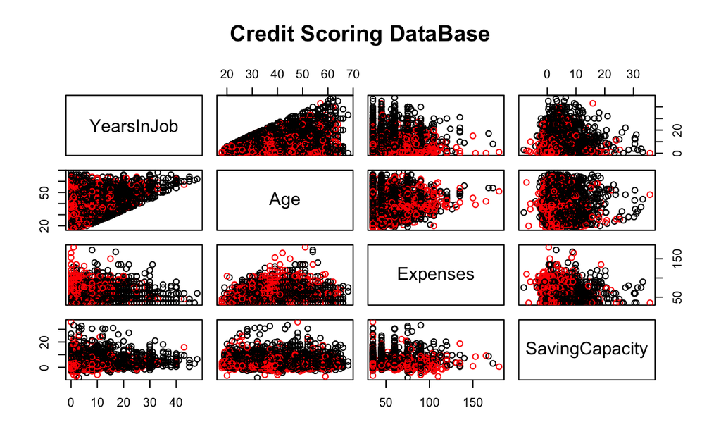

```r
# (this plot shows how difficult this problem is)
pairs(Credit.new[,c(2,5,9,16)], main = "Credit Scoring DataBase", col = (1:length(levels(Credit.new$Assessment)))[unclass(Credit.new$Assessment)])
```

##### Feature selection for continuous variables using Fisher’s F

```r
names(Credit.new)[range.cont]
```

```
 [1] "YearsInJob"       "Deadline"         "Age"              "Expenses"
 [5] "Income"           "Capital"          "ChargesOnCapital" "AmountRequested"
 [9] "MarketPrice"      "FinancingRatio"   "SavingCapacity"
```

```r
pvalcon = NULL

varc = list(YearsInJob, Deadline, Age, Expenses, Income, Capital, ChargesOnCapital, AmountRequested, MarketPrice, FinancingRatio, SavingCapacity)

for (i in 1:length(varc))
  pvalcon[i] = (oneway.test(varc[[i]]~Credit.new$Assessment))$p.value

pvalcon = matrix(pvalcon)
row.names(pvalcon) = colnames(Credit.new)[range.cont]

# Ordered list of continuous variables according to their association to Assessment (more to less association)

as.matrix(sort(pvalcon[,1]))
```

```
                         [,1]
YearsInJob       1.377826e-88
FinancingRatio   2.337194e-59
SavingCapacity   4.341778e-33
AmountRequested  3.566744e-21
Income           8.836794e-19
Deadline         4.359567e-13
Age              6.187769e-11
Capital          1.223170e-07
Expenses         6.427055e-02
MarketPrice      5.259756e-01
ChargesOnCapital 5.344471e-01
```

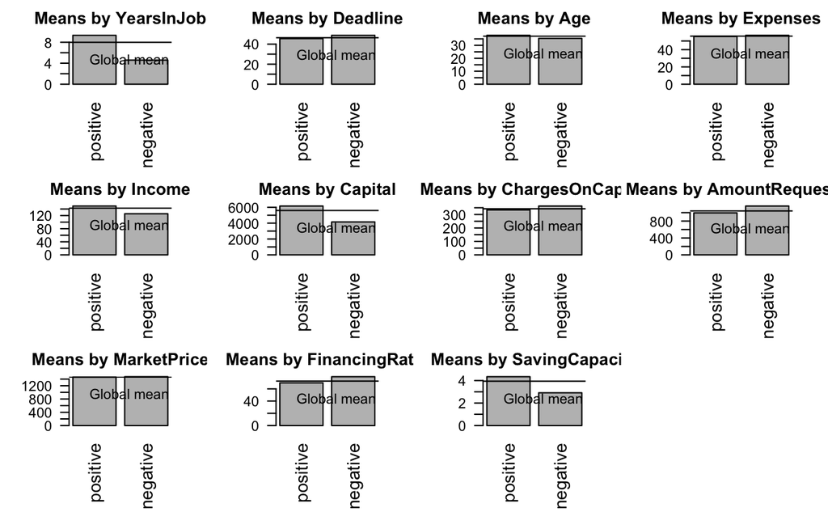

```r
# Graphical representation of Assessment

ncon = nrow(pvalcon)

par (mfrow=c(3,4))

for (i in 1:ncon)
{
  barplot (tapply(varc[[i]], Credit.new$Assessment, mean),main=paste("Means by",row.names(pvalcon)[i]), las=2, cex.names=1.25)
  abline (h=mean(varc[[i]]))
  legend (0,mean(varc[[i]]),"Global mean",bty="n")
}
```

##### Feature selection using pair-wise Pearson correlations

```r
# Compute and show the 10 most mosthighly correlated variables
mosthighlycorrelated(Credit.new[,range.cont], 10)
```

|  | First.Variable | Second.Variable | Correlation |
| --- | --- | --- | --- |
| 96 | AmountRequested | MarketPrice | 0.7250254 |
| 115 | Income | SavingCapacity | 0.7185808 |
| 23 | YearsInJob | Age | 0.5060887 |
| 107 | AmountRequested | FinancingRatio | 0.4738421 |
| 101 | Deadline | FinancingRatio | 0.4686413 |
| 79 | Deadline | AmountRequested | 0.4308583 |
| 36 | Age | Expenses | 0.2481369 |
| 48 | Expenses | Income | 0.2453146 |
| 60 | Income | Capital | 0.2236435 |
| 93 | Income | MarketPrice | 0.2208331 |

#### SECTION 9: Miscellaneous issues

Shuffle the data (to avoid possible biases)

```r
set.seed (104)
Credit.new = Credit.new[sample.int(nrow(Credit.new)),]
```

#### SECTION 10: Save the preprocessed data into a file for future use

```r
# WARNING! This is a binary file, unless 'ascii' is TRUE
save(Credit.new, file = "Credsco-processed.Rdata")
```

Cleanup:

```r
# remove (almost) everything in the working environment
rm(list = ls())

load("Credsco-processed.Rdata")
objects()
```

```
[1] "Credit.new"
```